# Comparaison FROGS/MOTHUR/UPARSE sur la banque silva

Mahendra Mariadassou, Géraldine Pascal

17 juin 2016

# 1 Introduction

Ce document R markdown a vocation à documenter la procédure suivie pour comparer les résultats de FROGS, Mothur et UParse sur les jeux de données simulées. En particulier, on cherche à savoir si Frogs permet d’avoir une vision taxonomique des communautés bactériennes plus fidèle que Mothur et UParse.

# 2 Import et préparation des données

## 2.1 Chargement des packages

On commence par charger quelques packages utiles: - reshape et dplyr pour la manipulation de données - ggplot2, grid et gridExtra pour la visualisation - dunn.test pour effectuer des tests de Dunn (version non paramétrique du test post-hoc de Tukey)

```r
library(ggplot2)
library(grid)
library(gridExtra)
library(reshape2)
library(dunn.test)
library(dplyr)
```

et une fonction utilitaire pour combiner plusieurs graphiques ggplot:

```r
## http://stackoverflow.com/questions/13649473/add-a-common-legend-for-combined-ggplots
grid_arrange_shared_legend <- function(..., ncol = 1) {
  require(grid)
    plots <- list(...)
    g <- ggplotGrob(plots[[1]] + theme(legend.position="bottom"))$grobs
    legend <- g[[which(sapply(g, function(x) x$name) == "guide-box")]]
    lheight <- sum(legend$height)
    grid.arrange(
        do.call(arrangeGrob, c(lapply(plots, function(x)
            x + theme(legend.position="none")), ncol = ncol)),
        legend,
        nrow = 2,
        heights = unit.c(unit(1, "npc") - lheight, lheight))
}
```

## 2.2 Import des données

On importe ensuite les données

```r
data.silva <- read.table("silva.tsv", sep = "\t", header = TRUE)
head(data.silva)
```

```
##   databank nb_OTU   dataset set_number amplicon abundance_law method
## 1    silva   20sp dataset_1       set1     V3V4      powerlaw mothur
## 2    silva   20sp dataset_1       set2     V3V4      powerlaw mothur
## 3    silva   20sp dataset_1       set3     V3V4      powerlaw mothur
## 4    silva   20sp dataset_1       set4     V3V4      powerlaw mothur
## 5    silva   20sp dataset_1       set5     V3V4      powerlaw mothur
## 6    silva   20sp dataset_1       set6     V3V4      powerlaw mothur
##    Species     Genus    Family     Order     Class    Phylum
## 1 3.301998 1.3995125 1.3182243 1.2685342 1.2080081 0.2456722
## 2 5.280848 1.4678637 1.4275240 1.4275240 1.4275240 1.3442830
## 3 1.711422 1.0088024 0.9995520 0.9995520 0.9995520 0.2911754
## 4 1.925666 0.9188980 0.8272826 0.7641863 0.7547615 0.4669847
## 5 5.346080 1.3983519 1.3514173 1.3503893 1.3341160 1.0098468
## 6 4.630647 0.8412553 0.7950950 0.7659827 0.7659827 0.3455143
```

## 2.3 Transformation des données

Les différentes réponses d’intéret sont Species, Genus, Family, Order, Class, Phylum stockées sur plusieurs colonnes. Avant toute chose, on change la variale nb_OTU en une variable numérique (pour retrouver un ordonnancement naturel)

```r
data.silva$nb_OTU <- as.numeric(sub("sp", "", data.silva$nb_OTU))
```

```r
data.silva <- data.silva %>%
  melt(id.vars = c("databank", "nb_OTU", "dataset", "set_number", "amplicon", "abundance_law", "method"),
       value.name = "divergence",
       variable.name = "rank")
head(data.silva)
```

```
##   databank nb_OTU   dataset set_number amplicon abundance_law method
## 1    silva     20 dataset_1       set1     V3V4      powerlaw mothur
## 2    silva     20 dataset_1       set2     V3V4      powerlaw mothur
## 3    silva     20 dataset_1       set3     V3V4      powerlaw mothur
## 4    silva     20 dataset_1       set4     V3V4      powerlaw mothur
## 5    silva     20 dataset_1       set5     V3V4      powerlaw mothur
## 6    silva     20 dataset_1       set6     V3V4      powerlaw mothur
##      rank divergence
## 1 Species   3.301998
## 2 Species   5.280848
## 3 Species   1.711422
## 4 Species   1.925666
## 5 Species   5.346080
## 6 Species   4.630647
```

On va aussi construire un autre tableau qui intégre le fait que frogs constitue notre méthode de référence et qu’on compare, sur chaque échantillon, une méthode concurrente à la méthode de référence.

```r
data.silva.2 <- data.silva %>% dcast(databank + nb_OTU + dataset + set_number + amplicon + abundance_law + rank ~ method) %>%
  melt(id.vars = c("databank", "nb_OTU", "dataset", "set_number", "amplicon", "abundance_law", "rank", "frogs"),
       value.name = "divergence",
       variable.name = "method")
head(data.silva.2)
```

```
##   databank nb_OTU   dataset set_number amplicon abundance_law    rank
## 1    silva     20 dataset_1       set1     V3V4      powerlaw Species
## 2    silva     20 dataset_1       set1     V3V4      powerlaw   Genus
## 3    silva     20 dataset_1       set1     V3V4      powerlaw  Family
## 4    silva     20 dataset_1       set1     V3V4      powerlaw   Order
## 5    silva     20 dataset_1       set1     V3V4      powerlaw   Class
## 6    silva     20 dataset_1       set1     V3V4      powerlaw  Phylum
##       frogs method divergence
## 1 1.3004167 mothur  3.3019980
## 2 1.3004167 mothur  1.3995125
## 3 1.2301349 mothur  1.3182243
## 4 1.1895285 mothur  1.2685342
## 5 1.1389845 mothur  1.2080081
## 6 0.2175822 mothur  0.2456722
```

Dans data.silva.2, *divergence* correspond à la divergence mesurée sur une méthode concurrente (renseignée dans *method*) tandis que *frogs* correspond à la divergence mesurée par FROGS.

## 2.4 Visualisation des données

Avant de s’attaquer aux tests, on va comparer visuellement les niveaux de divergence obtenus. Pour insister sur la structure pairée des données (les divergences sont mesurées sur les **mêmes échantillons**) et sur le fait que Frogs est la méthode de référence, on va comparer les taux de divergences de Mothur à Frogs et de Uparse à Frogs.

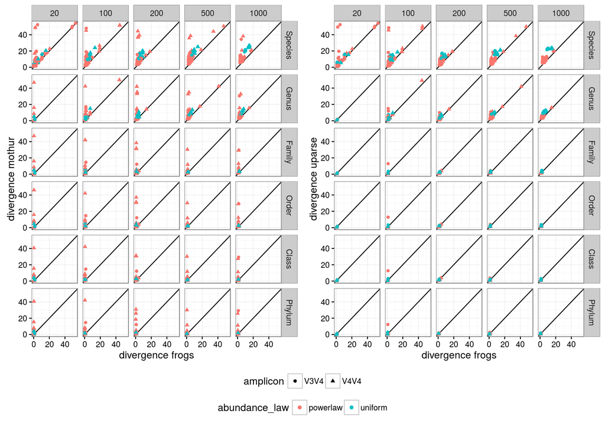

```r
p <- ggplot(mapping = aes(x = frogs, y = divergence, color = abundance_law, shape = amplicon)) + facet_grid(rank ~ nb_OTU) + geom_abline(slope = 1, intercept = 0) + theme_bw()
p.mothur <- p + geom_point(data = filter(data.silva.2, method == "mothur")) + labs(x = "divergence frogs", y = "divergence mothur")
p.uparse <- p + geom_point(data = filter(data.silva.2, method == "uparse")) + labs(x = "divergence frogs", y = "divergence uparse")
grid_arrange_shared_legend(p.mothur, p.uparse, ncol = 2)
```

On remarque que l’immense majorité des échantillons sont au dessus ou proche de la première bissectrice (droite y = x), ce qui signifie que FROGS a des performances meilleures ou comparables à ses deux concurrents.

On peut aussi adopter une représentation plus classique des résultats à base de boxplot

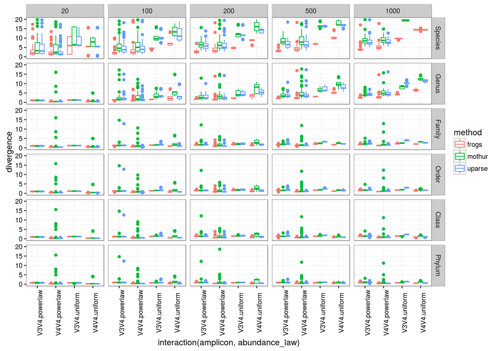

```r
p <- ggplot(data.silva, mapping = aes(x = interaction(amplicon, abundance_law), y = divergence, color = method)) + facet_grid(rank ~ nb_OTU) + geom_boxplot() + theme_bw() + scale_y_continuous(limits = c(0, 20)) + theme(axis.text.x = element_text(angle = 90))
plot(p)
```

# 3 Comparaison des méthodes

L’unité d’intéret la plus fine est la communauté théorique. Pour chaque communauté théorique, on veut savoir si FROGS reconstruit *mieux* la communauté que les méthodes concurrentes. Les réplicats techniques permettent de déterminer si la reconstruction de FROGS est *significativement* meilleure (ou pire) que celles de ses concurrentes. En aggrégant les résultats sur les communautés théoriques, on pourra déterminer dans quelles régions de l’espace des paramètres FROGS fait mieux, moins bien ou pareil que les méthodes concurrentes.

## 3.1 Test de student pairé

Le test adopté (au niveau des réplicats techniques d’une communauté biologique) est un test de Student pairé (les divergences sur mesurées sur les mêmes échantillons). On peut aussi envisager sa contrepartie non-paramètrique: un test de Mann-Whitney contre l’hypothèse nulle $\mu = 0$ (pas de différence significative de divergence entre les méthodes). Cette étude est reportée à la section suivante.

```r
silva.t.test <- data.silva.2 %>% group_by(databank, nb_OTU, dataset, amplicon, abundance_law, rank, method) %>%
  summarize(pval = t.test(frogs, divergence, paired = TRUE)$p.value,
            measure = t.test(frogs, divergence, paired = TRUE)$estimate) %>%
  mutate(best = ifelse(measure >0, "competitor", "frogs")) %>%
  mutate(best = ifelse(pval < 0.05, best, "tied")) %>%
  mutate(best = factor(best, levels = c("frogs", "tied", "competitor")))
silva.t.test %>% select(measure, pval, best) %>% head()
```

```
## Source: local data frame [6 x 9]
## Groups: databank, nb_OTU, dataset, amplicon, abundance_law, rank [3]
##
##   databank nb_OTU   dataset amplicon abundance_law    rank     measure
##     (fctr)  (dbl)    (fctr)   (fctr)        (fctr)  (fctr)       (dbl)
## 1    silva     20 dataset_1     V3V4      powerlaw Species -2.09159108
## 2    silva     20 dataset_1     V3V4      powerlaw Species -1.97526246
## 3    silva     20 dataset_1     V3V4      powerlaw   Genus  0.04358030
## 4    silva     20 dataset_1     V3V4      powerlaw   Genus  0.02241534
## 5    silva     20 dataset_1     V3V4      powerlaw  Family  0.07374767
## 6    silva     20 dataset_1     V3V4      powerlaw  Family  0.02409343
## Variables not shown: pval (dbl), best (fctr)
```

Dans le tableau précédent, la colonne *mesure* représente l’écart de divergence moyenn entre frogs et son compétiteur (pour une communauté théorique donnée), *pval* correspond à la p-valeur associée à cette écart et *best* indique la meilleure des deux méthodes (*frogs*, *competitor* ou *tied* si on ne peut pas les distinguer).

Il ne reste plus qu’à représenter les données pour savoir dans quelles circonstances frogs fait mieux que la compétition.

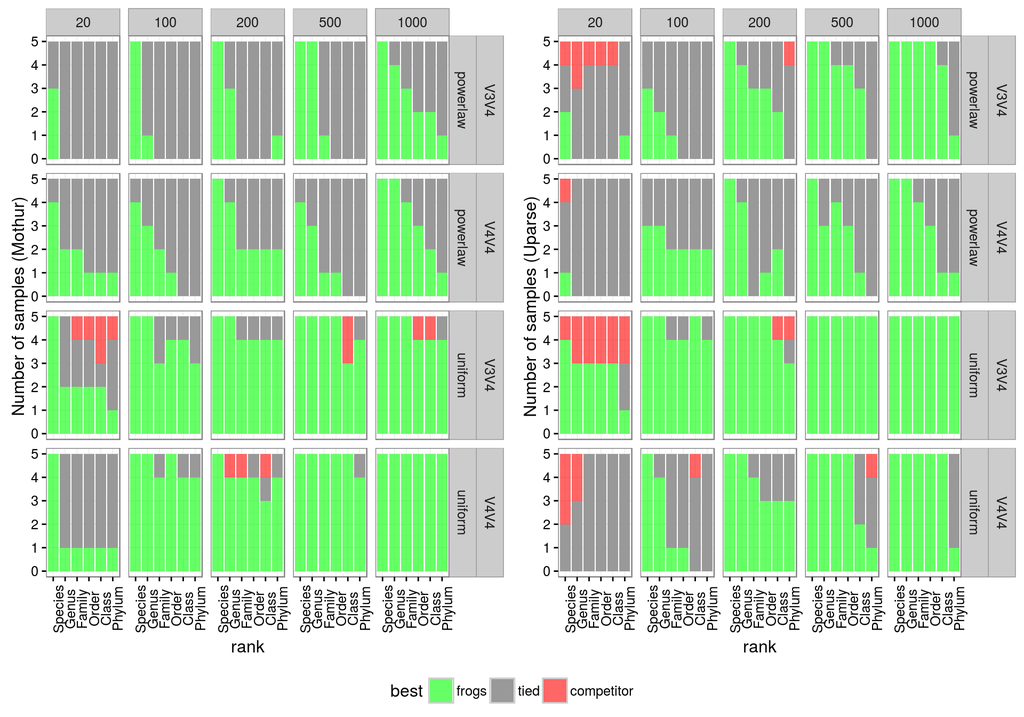

```r
frogs.color <- rgb(0, 1, 0, alpha = 0.6, maxColorValue = 1)
competitor.color <- rgb(1, 0, 0, alpha = 0.6, maxColorValue = 1)
p <- ggplot(mapping = aes(x = rank, fill = best)) + facet_grid(abundance_law + amplicon ~ nb_OTU) + theme_bw() + scale_fill_manual(values = setNames(c(frogs.color, "grey60", competitor.color), c("frogs", "tied", "competitor"))) + theme(axis.text.x = element_text(angle = 90))
p.mothur <- p + geom_bar(data = filter(silva.t.test, method == "mothur")) + ylab("Number of samples (Mothur)")
p.uparse <- p + geom_bar(data = filter(silva.t.test, method == "uparse")) + ylab("Number of samples (Uparse)")
grid_arrange_shared_legend(p.mothur, p.uparse, ncol = 2)
```

Les graphiques montrent bien que dans la majorité des cas, FROGS est significativement meilleur ou équivalent à la méthode concurrente. FROGS fait mieux que la concurrence aux niveaux taxonomiques profonds (Species, Genus), en présence de beaucoup d’espèces et avec des distributions d’abondance uniformes.

## 3.2 Test pairé non paramétrique

On adopte ici la même approche mais avec un test non paramétrique: un test de Mann-Whitney contre l’hypothèse nulle $\mu = 0$ (pas de différence significative de divergence entre les méthodes).

```r
silva.wilcox.test <- data.silva.2 %>% group_by(databank, nb_OTU, dataset, amplicon, abundance_law, rank, method) %>%
  summarize(pval = wilcox.test(frogs, divergence, paired = TRUE)$p.value,
            measure = wilcox.test(frogs, divergence, paired = TRUE, conf.int = TRUE)$estimate) %>%
  mutate(best = ifelse(measure >0, "competitor", "frogs")) %>%
  mutate(best = ifelse(pval < 0.05, best, "tied")) %>%
  mutate(best = factor(best, levels = c("frogs", "tied", "competitor")))
silva.wilcox.test %>% select(measure, pval, best) %>% head()
```

```
## Source: local data frame [6 x 9]
## Groups: databank, nb_OTU, dataset, amplicon, abundance_law, rank [3]
##
##   databank nb_OTU   dataset amplicon abundance_law    rank     measure
##     (fctr)  (dbl)    (fctr)   (fctr)        (fctr)  (fctr)       (dbl)
## 1    silva     20 dataset_1     V3V4      powerlaw Species -2.14587531
## 2    silva     20 dataset_1     V3V4      powerlaw Species -2.04963154
## 3    silva     20 dataset_1     V3V4      powerlaw   Genus  0.06134262
## 4    silva     20 dataset_1     V3V4      powerlaw   Genus  0.02222643
## 5    silva     20 dataset_1     V3V4      powerlaw  Family  0.09336344
## 6    silva     20 dataset_1     V3V4      powerlaw  Family  0.02477687
## Variables not shown: pval (dbl), best (fctr)
```

Il ne reste plus qu’à représenter les données pour savoir dans quelles circonstances frogs fait mieux que la compétition.

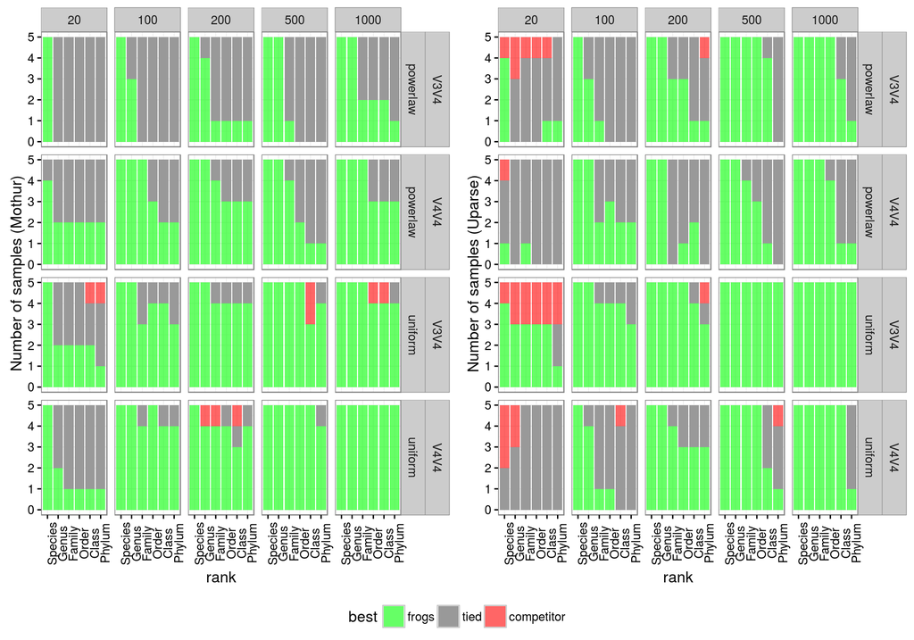

```r
frogs.color <- rgb(0, 1, 0, alpha = 0.6, maxColorValue = 1)
competitor.color <- rgb(1, 0, 0, alpha = 0.6, maxColorValue = 1)
p <- ggplot(mapping = aes(x = rank, fill = best)) + facet_grid(abundance_law + amplicon ~ nb_OTU) + theme_bw() + scale_fill_manual(values = setNames(c(frogs.color, "grey60", competitor.color), c("frogs", "tied", "competitor"))) + theme(axis.text.x = element_text(angle = 90))
p.mothur <- p + geom_bar(data = filter(silva.wilcox.test, method == "mothur")) + ylab("Number of samples (Mothur)")
p.uparse <- p + geom_bar(data = filter(silva.wilcox.test, method == "uparse")) + ylab("Number of samples (Uparse)")
grid_arrange_shared_legend(p.mothur, p.uparse, ncol = 2)
```

avec les mêmes résultats que précédemment.